# 20212_M2.855_PEC3_Enunciado

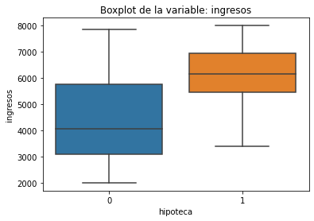

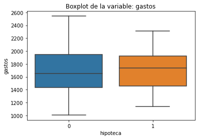

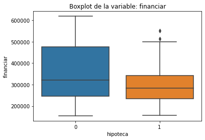

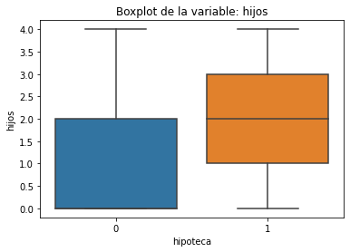

```python
numericFeatures = ["ingresos","gastos","financiar","hijos"]

for i in numericFeatures:
    print("")
    sns.boxplot( x=hipotecas["hipoteca"], y=hipotecas[i]).set(title='Boxplot de la variable: {}'.format(str(i)))
    #plt.show()

    plt.show()
```

La mediana en el monto a financiar es menor en el grupo de personas a las que les aprueban la hipóteca

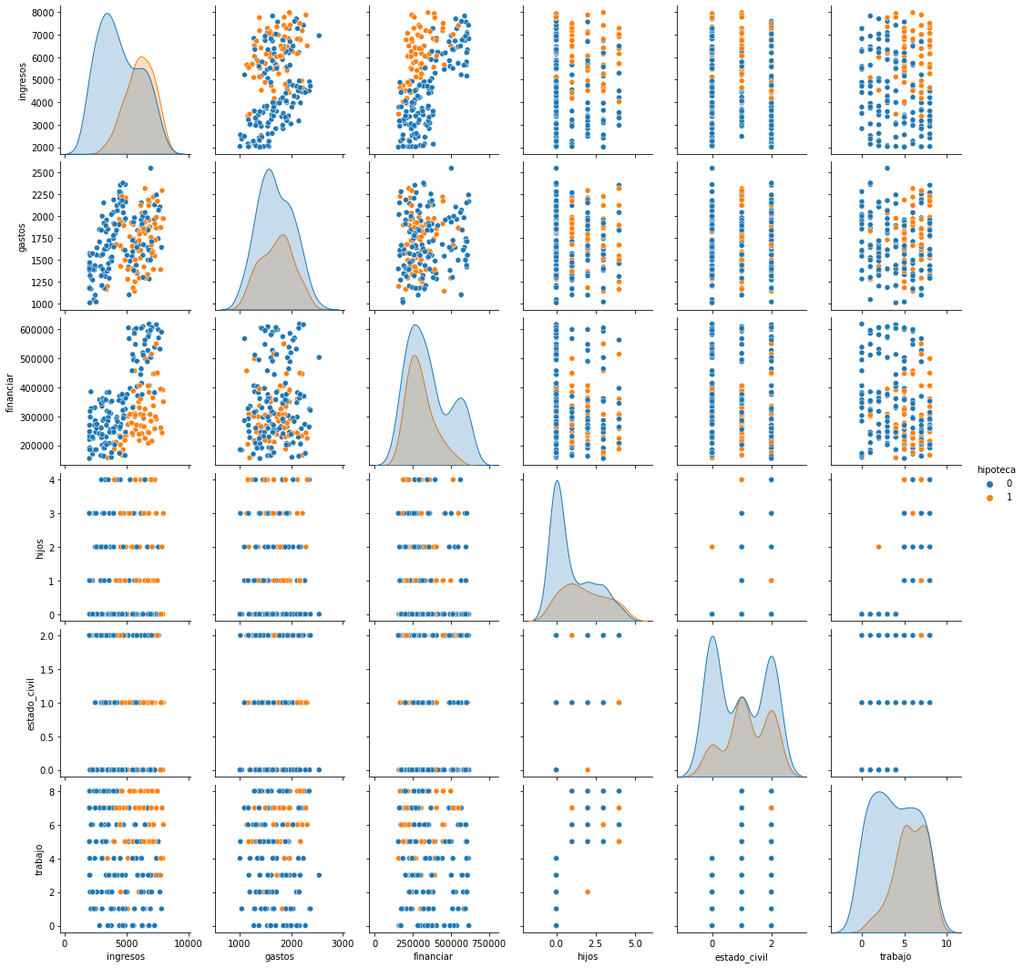

```python
sns.pairplot(hipotecas, hue="hipoteca")
```

Finalmente, sólo nos queda pasar las variables categóricas a numéricas. Observad que a pesar de que todas las variables tengan números, esto no quiere decir que sean numéricas. Por ejemplo, la variable `estado_civil` tiene los valores 0-1-2, que sería lo mismo que si tuviera los valores soltero-casado-divorciado. Hay otras variables donde esto no ocurre, por ejemplo el número de hijos, que a pesar de ser categórica sí que son números, ya que es ordinal. La manera de diferenciarlo es, en el caso del número de hijos, 1 hijo es menos que 2 hijos, mientras que con el estado civil no hay un orden.

Una manera de pasar las variables categóricas en numéricas es aplicando *one-hot encoding*. Por ejemplo, en el caso de la variable `estado_civil`, lo que se haría sería crear tres columnas nuevas: `soltero`, `casado` y `divorciado`. Estas columnas tendrían los valores 0-1, por ejemplo, en el caso de la columna `soltero` tendría el valor 1 cuando `estado_civil = soltero`, y cero en otro caso.

**Implementación:** Aplica _one-hot-encoding_ a las variables categóricas que lo requieran. No olvidéis eliminar las variables originales! Podéis utilizar `OneHotEncoder` de `sklearn.preprocessing`.

```python
hipotecas.head(2)
```

|  | ingresos | gastos | financiar | hijos | estado_civil | trabajo | hipoteca |
| --- | --- | --- | --- | --- | --- | --- | --- |
| 0 | 6000 | 1600 | 350000 | 2 | 0 | 2 | 1 |
| 1 | 6745 | 1496 | 593657 | 3 | 1 | 6 | 0 |

Con la función get dummies podemos realizar el one hot encoding necesario y usando el argumento drop first nos aseguramos de borrar al menos una columna por variable que ha sufrido la transformación para evitar la dependencia lineal entre las nuevas columnas. Se asume que el número de hijos es una variable númerica

```python
hipotecas_proc =pd.get_dummies(hipotecas, columns = ["estado_civil", "trabajo"], drop_first=True)
hipotecas_proc.head()
```

|  | ingresos | gastos | financiar | hijos | hipoteca | estado_civil_1 | estado_civil_2 | trabajo_1 | trabajo_2 | trabajo_3 | trabajo_4 | trabajo_5 | trabajo_6 | trabajo_7 | trabajo_8 |
| --- | --- | --- | --- | --- | --- | --- | --- | --- | --- | --- | --- | --- | --- | --- | --- |
| 0 | 6000 | 1600 | 350000 | 2 | 1 | 0 | 0 | 0 | 1 | 0 | 0 | 0 | 0 | 0 | 0 |
| 1 | 6745 | 1496 | 593657 | 3 | 0 | 1 | 0 | 0 | 0 | 0 | 0 | 0 | 1 | 0 | 0 |
| 2 | 6455 | 1926 | 264316 | 1 | 1 | 0 | 1 | 0 | 0 | 0 | 0 | 0 | 0 | 0 | 1 |
| 3 | 7098 | 1547 | 606427 | 0 | 0 | 0 | 0 | 0 | 0 | 1 | 0 | 0 | 0 | 0 | 0 |
| 4 | 6167 | 1606 | 307420 | 0 | 1 | 0 | 0 | 0 | 0 | 1 | 0 | 0 | 0 | 0 | 0 |

```python
hipotecas_proc.columns
```

```
Index(['ingresos', 'gastos', 'financiar', 'hijos', 'hipoteca',
       'estado_civil_1', 'estado_civil_2', 'trabajo_1', 'trabajo_2',
       'trabajo_3', 'trabajo_4', 'trabajo_5', 'trabajo_6', 'trabajo_7',
       'trabajo_8'],
      dtype='object')
```

```python
X = hipotecas_proc[['ingresos', 'gastos', 'financiar', 'hijos',
                    'estado_civil_1', 'estado_civil_2', 'trabajo_1', 'trabajo_2',
                    'trabajo_3', 'trabajo_4', 'trabajo_5', 'trabajo_6', 'trabajo_7',
                    'trabajo_8']]
```

```python
X.head(2)
```

|  | ingresos | gastos | financiar | hijos | estado_civil_1 | estado_civil_2 | trabajo_1 | trabajo_2 | trabajo_3 | trabajo_4 | trabajo_5 | trabajo_6 | trabajo_7 | trabajo_8 |
| --- | --- | --- | --- | --- | --- | --- | --- | --- | --- | --- | --- | --- | --- | --- |
| 0 | 6000 | 1600 | 350000 | 2 | 0 | 0 | 0 | 1 | 0 | 0 | 0 | 0 | 0 | 0 |
| 1 | 6745 | 1496 | 593657 | 3 | 1 | 0 | 0 | 0 | 0 | 0 | 0 | 1 | 0 | 0 |

```python
y = hipotecas_proc[["hipoteca"]]
y.head(2)
```

|  | hipoteca |
| --- | --- |
| 0 | 1 |
| 1 | 0 |

Estandarizamos los datos para probar contra los datos originales ya procesados

```python
from sklearn.preprocessing import StandardScaler



X_scaled = StandardScaler().fit_transform(X)
```

```python
X_scaled
```

```
array([[ 0.62012866, -0.30476059,  0.12193859, ..., -0.35845728,
        -0.3927922 , -0.4094265 ],
       [ 1.0639266 , -0.62571561,  2.05123292, ...,  2.78973273,
        -0.3927922 , -0.4094265 ],
       [ 0.89117304,  0.70130992, -0.55651373, ..., -0.35845728,
        -0.3927922 ,  2.44244084],
       ...,
       [-1.05736798,  0.66736276,  0.14141705, ..., -0.35845728,
        -0.3927922 ,  2.44244084],
       [-0.96801269,  0.5840379 ,  0.17662873, ..., -0.35845728,
        -0.3927922 , -0.4094265 ],
       [-0.57842363, -0.16897194, -0.70470842, ..., -0.35845728,
        -0.3927922 , -0.4094265 ]])
```

**Análisis:** - ¿Por qué es necesario hacer _one-hot encoding_? - ¿Qué diferencia hay entre tener una columna `estado_civil` o tres columnas `soltero`, `casado` y `divorciado` si la información es la misma? - ¿Por qué es incorrecto a nivel conceptual dejar las variables tal y como las teníamos, si eran números y el modelo hubiera funcionado?

- Es necesaria hacer la transformación debido a que los algoritmos que utilizamos no admiten como entrada datos categóricos y el tratamiento correspondiente es transformar esas variables a variables de 0 y 1 que responden al criterio ausencia o presencia y si serían númericas.
- La información es la misma pero es interpretada por el modelo de forma diferente: si casado vale 1 y divorciado 2, el modelo interpreta que divorciado vale el doble que estar casado y esto es una representación irreal de los datos, principalmente porque la escala no es ordinal o númerica, sino categórica.
- Como se mencionó con anterioridad es un error conceptual por las escalas de medida de las variable y su interpretación dentro del modelo

### 2.3. Entrenamiento de un modelo

Ahora que ya tenemos el *dataset* limpio y hemos hecho un análisis de las diferentes variables, podemos proceder a entrenar un modelo para predecir si se concede una hipoteca o no.

Probaremos con 2 modelos diferentes e interpretaremos los resultados.

Para empezar, separamos el dataset entre *train* y *test*.

**Implementación:** Dividid el _dataset_ en dos subconjuntos: _train_ (80% de los datos) y _test_ (20% de los datos). Nombrad los conjuntos: X_train, X_test, y_train, y_test. Utilizad la opción `random_state = 24`. Podéis utilizar la implementación `train_test_split` de `sklearn`.

```python
X_train, X_test, y_train, y_test = train_test_split(X, y,
                                                    test_size=0.20,
                                                    random_state=24)

X_train_scaled, X_test_scaled, y_train_scaled, y_test_scaled = train_test_split(X_scaled, y,
                                                                                test_size=0.20,
                                                                                random_state=24)
```

**Implementación:** Utilizad un árbol de decisión simple con `max_depth = 5` para acotar el dataset "hipotecas" sobre el conjunto de _train_. Dibujad el árbol de decisión. Calculad el _accuray_ y la matriz de confusión sobre _train_ y sobre _test_. Para dibujar el árbol, podéis guiaros con este enlace: https://towardsdatascience.com/visualizing-decision-trees-with-python-scikit-learn-graphviz-matplotlib-1c50b4aa68dc

```python
tree_1 = DecisionTreeClassifier(max_depth=5)

tree_1.fit(X_train, y_train)

y_pred_1 = tree_1.predict(X_test)
y_pred_1_train = tree_1.predict(X_train)


print("Accuracy del modelo sobre los datos test: {}".format(accuracy_score(y_test, y_pred_1)))
print("Accuracy del modelo sobre los datos train: {}".format(accuracy_score(y_train, y_pred_1_train)))
```

```
Accuracy del modelo sobre los datos test: 0.8292682926829268
Accuracy del modelo sobre los datos train: 0.9937888198757764
```

```python
# Test

cm = pd.DataFrame(
    confusion_matrix(y_test, y_pred_1),
    index= target_names,
    columns=target_names
)
cm
```

|  | 1 | 0 |
| --- | --- | --- |
| 1 | 24 | 4 |
| 0 | 3 | 10 |

```python
print(classification_report(y_test, y_pred_1))
```

```
              precision    recall  f1-score   support

           0       0.89      0.86      0.87        28
           1       0.71      0.77      0.74        13

    accuracy                           0.83        41
   macro avg       0.80      0.81      0.81        41
weighted avg       0.83      0.83      0.83        41
```

```python
# Train

cm = pd.DataFrame(
    confusion_matrix(y_train, y_pred_1_train),
    index= target_names,
    columns=target_names
)
cm
```

|  | 1 | 0 |
| --- | --- | --- |
| 1 | 107 | 0 |
| 0 | 1 | 53 |

```python
print(classification_report(y_train, y_pred_1_train))
```

```
              precision    recall  f1-score   support

           0       0.99      1.00      1.00       107
           1       1.00      0.98      0.99        54

    accuracy                           0.99       161
   macro avg       1.00      0.99      0.99       161
weighted avg       0.99      0.99      0.99       161
```

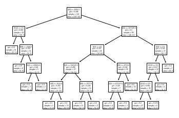

```python
from sklearn import tree

tree.plot_tree(tree_1);
```

```python
pip install graphviz
```

```python
from IPython.display import display
import graphviz
```

```python
def plot_decision_tree(model, featureNames, classNames):
    cn=['0', '1', '2']

    dot_data = StringIO()
    export_graphviz(model,
                    feature_names = featureNames,
                    class_names= classNames,
                    out_file=dot_data,
                    filled=True, rounded=True,
                    special_characters=True)
    graph = pydotplus.graph_from_dot_data(dot_data.getvalue())
    return Image(graph.create_png())
```

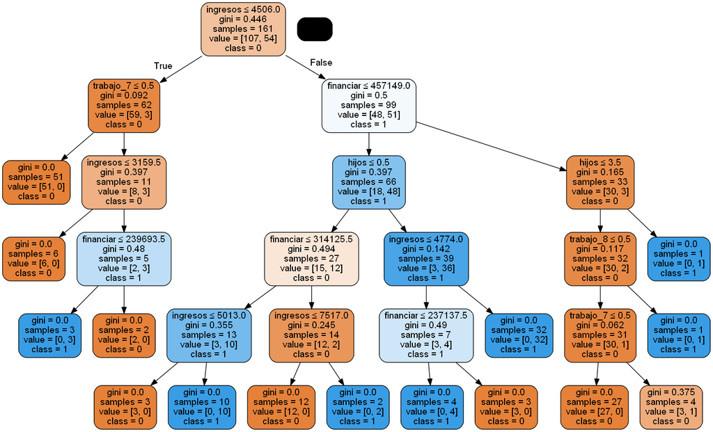

```python
plot_decision_tree(tree_1, list(X.columns),["0","1"])
```

Prueba con el data set scaled

```python
tree_2 = DecisionTreeClassifier(max_depth=5)

tree_2.fit(X_train_scaled, y_train_scaled)

y_pred_2 = tree_2.predict(X_test_scaled)
y_pred_2_train = tree_2.predict(X_train_scaled)


print("Accuracy del modelo sobre los datos test: {}".format(accuracy_score(y_test_scaled, y_pred_2)))
print("Accuracy del modelo sobre los datos train: {}".format(accuracy_score(y_train_scaled, y_pred_2_train)))
```

```
Accuracy del modelo sobre los datos test: 0.8292682926829268
Accuracy del modelo sobre los datos train: 0.9937888198757764
```

La performance es similar si los datos son estandarizados

**Análisis:** Interpretad el árbol de decisión: - ¿Cuáles son las variables que han tenido más peso? - ¿Has obtenido una buena precisión evaluando en test? - ¿Se ha producido _overfitting_?

La siguiente forma de graficar los features fue tomada como referencia de:

- Brownlee J. (2020). How to Calculate Feature Importance With Python. https://machinelearningmastery.com/calculate-feature-importance-with-python/

```
Feature 0: ingresos, Importance: 0.4088
Feature 1: gastos, Importance: 0.0
Feature 2: financiar, Importance: 0.4117
Feature 3: hijos, Importance: 0.1283
Feature 4: estado_civil_1, Importance: 0.0
Feature 5: estado_civil_2, Importance: 0.0
Feature 6: trabajo_1, Importance: 0.0
Feature 7: trabajo_2, Importance: 0.0
Feature 8: trabajo_3, Importance: 0.0
Feature 9: trabajo_4, Importance: 0.0
Feature 10: trabajo_5, Importance: 0.0
Feature 11: trabajo_6, Importance: 0.0
Feature 12: trabajo_7, Importance: 0.0254
```

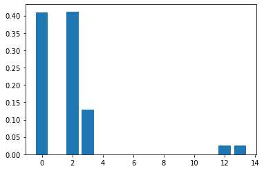

```python
importance = tree_1.feature_importances_

for i,e,o in zip(list(range(0,13)),list(X.columns), importance):
    print("Feature {}: {}, Importance: {}".format(i,e,round(o,4)))

# plot feature importance
plt.bar([x for x in range(len(importance))], importance)
plt.show()
```

- Las variables con mayor peso que explican si una hipoteca es concedida o no son los ingresos y el monto total a financiar.
- El modelo tiene una precisión alta para detectar a las personas a las que no se les concede el servicio y moderada para las que si. Por lo tanto la métrica es regular.
- Hay evidencia de overfitting o sobre entrenamiento porque la performance general, el accuracy y la precisión son mucho mayores sobre el conjunto de entrenamiento

**Implementación:** Usad _Random Forest_ o _Gradient Boosting_ para acotar el _dataset_ "hipotecas". Esta vez vamos a optimizar el modelo para obtener los mejores resultados posibles. Tal y como hemos visto en el ejercicio anterior, recuerda seguir los siguientes pasos: - Utilizar el _dataset_ de _train_ para encontrar los mejores hiperparámetros haciendo _cross-validation_. - Entrenar el modelo con _train_, predecir con test y calcular su _accuracy_ y la matriz de confusión.

```python
randomForestparameters = {
                         #'bootstrap': True,
                         'criterion': ["gini", "entropy"],
                         'max_depth': [8,9,10,11,12,13,14,15],
                         'n_estimators': [50,100,200,300],

                         }



randomForestModels = GridSearchCV(RandomForestClassifier(), param_grid = randomForestparameters,
                                  #scoring = 'precision',
                                  scoring = ['accuracy', 'precision'], refit=False,
                                  cv = 4, n_jobs=-1)

randomForestModels.fit(X_train, y_train)
```

```
GridSearchCV(cv=4, estimator=RandomForestClassifier(), n_jobs=-1,
             param_grid={'criterion': ['gini', 'entropy'],
                         'max_depth': [8, 9, 10, 11, 12, 13, 14, 15],
                         'n_estimators': [50, 100, 200, 300]},
             refit=False, scoring=['accuracy', 'precision'])
```

```python
bestModelsRandomF = pd.DataFrame(randomForestModels.cv_results_)
```

```python
bestModelsRandomF.sort_values(by = "rank_test_accuracy").head()
```

|  | mean_fit_time | std_fit_time | mean_score_time | std_score_time | param_criterion | param_max_depth | param_n_estimators | params | split0_test_accuracy | split1_test_accuracy | ... | mean_test_accuracy | std_test_accuracy | rank_test_accuracy | split0_test_precision | split1_test_precision | split2_test_precision | split3_test_precision | mean_test_precision | std_test_precision | rank_test_precision |
| --- | --- | --- | --- | --- | --- | --- | --- | --- | --- | --- | --- | --- | --- | --- | --- | --- | --- | --- | --- | --- | --- |
| 34 | 0.742005 | 0.076020 | 0.048632 | 0.002942 | entropy | 8 | 200 | {'criterion': 'entropy', 'max_depth': 8, 'n_es... | 0.926829 | 0.925 | ... | 0.881707 | 0.045087 | 1 | 0.823529 | 1.0 | 1.0 | 0.769231 | 0.898190 | 0.103604 | 29 |
| 13 | 0.717667 | 0.077572 | 0.034002 | 0.002740 | gini | 11 | 100 | {'criterion': 'gini', 'max_depth': 11, 'n_esti... | 0.926829 | 0.900 | ... | 0.881707 | 0.037521 | 1 | 0.866667 | 1.0 | 1.0 | 0.769231 | 0.908974 | 0.097326 | 8 |
| 55 | 1.306132 | 0.098672 | 0.094756 | 0.017952 | entropy | 13 | 300 | {'criterion': 'entropy', 'max_depth': 13, 'n_e... | 0.926829 | 0.925 | ... | 0.881707 | 0.045087 | 1 | 0.823529 | 1.0 | 1.0 | 0.769231 | 0.898190 | 0.103604 | 29 |
| 0 | 0.290018 | 0.065480 | 0.023751 | 0.003898 | gini | 8 | 50 | {'criterion': 'gini', 'max_depth': 8, 'n_estim... | 0.951220 | 0.950 | ... | 0.881555 | 0.069620 | 4 | 0.875000 | 1.0 | 1.0 | 0.750000 | 0.906250 | 0.103645 | 13 |
| 43 | 1.314027 | 0.171102 | 0.077265 | 0.003544 | entropy | 10 | 300 | {'criterion': 'entropy', 'max_depth': 10, 'n_e... | 0.951220 | 0.925 | ... | 0.881555 | 0.057310 | 4 | 0.875000 | 1.0 | 1.0 | 0.769231 | 0.911058 | 0.096484 | 5 |

5 rows × 22 columns

```python
bestModelsRandomF.sort_values(by = "mean_test_precision").head()
```

|  | mean_fit_time | std_fit_time | mean_score_time | std_score_time | param_criterion | param_max_depth | param_n_estimators | params | split0_test_accuracy | split1_test_accuracy | ... | mean_test_accuracy | std_test_accuracy | rank_test_accuracy | split0_test_precision | split1_test_precision | split2_test_precision | split3_test_precision | mean_test_precision | std_test_precision | rank_test_precision |
| --- | --- | --- | --- | --- | --- | --- | --- | --- | --- | --- | --- | --- | --- | --- | --- | --- | --- | --- | --- | --- | --- |
| 40 | 0.286771 | 0.009337 | 0.026501 | 0.008381 | entropy | 10 | 50 | {'criterion': 'entropy', 'max_depth': 10, 'n_e... | 0.926829 | 0.825 | ... | 0.856707 | 0.048664 | 57 | 0.823529 | 0.875 | 0.900000 | 0.750000 | 0.837132 | 0.057366 | 64 |
| 49 | 0.453929 | 0.045929 | 0.033499 | 0.004387 | entropy | 12 | 100 | {'criterion': 'entropy', 'max_depth': 12, 'n_e... | 0.951220 | 0.900 | ... | 0.862805 | 0.065363 | 50 | 0.875000 | 1.000 | 0.857143 | 0.750000 | 0.870536 | 0.088726 | 63 |
| 61 | 0.475236 | 0.015881 | 0.036882 | 0.002753 | entropy | 15 | 100 | {'criterion': 'entropy', 'max_depth': 15, 'n_e... | 0.902439 | 0.900 | ... | 0.856860 | 0.051688 | 55 | 0.812500 | 1.000 | 1.000000 | 0.692308 | 0.876202 | 0.130888 | 61 |
| 28 | 0.242293 | 0.024589 | 0.035144 | 0.011832 | gini | 15 | 50 | {'criterion': 'gini', 'max_depth': 15, 'n_esti... | 0.902439 | 0.850 | ... | 0.838110 | 0.045919 | 64 | 0.812500 | 1.000 | 1.000000 | 0.692308 | 0.876202 | 0.130888 | 61 |
| 4 | 0.418559 | 0.126548 | 0.043752 | 0.022623 | gini | 9 | 50 | {'criterion': 'gini', 'max_depth': 9, 'n_estim... | 0.926829 | 0.900 | ... | 0.869207 | 0.057396 | 25 | 0.823529 | 1.000 | 1.000000 | 0.692308 | 0.878959 | 0.129627 | 60 |

5 rows × 22 columns

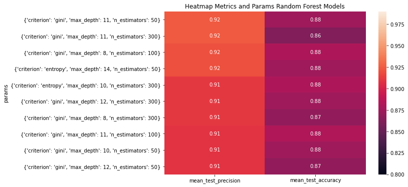

```python
dataRF = bestModelsRandomF[["params", "mean_test_precision", "mean_test_accuracy"]].set_index('params')
dataRF = dataRF.sort_values(by = ["mean_test_precision", "mean_test_accuracy"], ascending=False).head(10)
f, ax = plt.subplots(figsize=(9, 6))
sns.heatmap(dataRF, annot=True, ax=ax, vmin=0.80, vmax=0.99).set(title='Heatmap Metrics and Params Random Forest Models')
plt.show()
```

El rendimiento en relación a las métricas de todos los modelos es similar

```python
bestRandomForest = RandomForestClassifier(criterion="entropy", max_depth=14, n_estimators = 50)

bestRandomForest.fit(X_train, y_train)


y_pred = bestRandomForest.predict(X_test)
y_pred_train = bestRandomForest.predict(X_train)


print("Accuracy del modelo sobre los datos test: {}".format(accuracy_score(y_test, y_pred)))
print("Accuracy del modelo sobre los datos train: {}".format(accuracy_score(y_train, y_pred_train)))
```

```
Accuracy del modelo sobre los datos test: 0.8780487804878049
Accuracy del modelo sobre los datos train: 1.0
```

```python
cm = pd.DataFrame(
    confusion_matrix(y_test, y_pred),
    index= target_names,
    columns=target_names
)
cm
```

|  | 1 | 0 |
| --- | --- | --- |
| 1 | 27 | 1 |
| 0 | 4 | 9 |

```python
print(classification_report(y_test, y_pred))
```

```
              precision    recall  f1-score   support

           0       0.87      0.96      0.92        28
           1       0.90      0.69      0.78        13

    accuracy                           0.88        41
   macro avg       0.89      0.83      0.85        41
weighted avg       0.88      0.88      0.87        41
```

Un *Random Forest* / *Gradient Boosting* no es tan fácil de interpretar como un simple *Decision Tree*. No podemos dibujar el árbol, porque son combinaciones de muchos árboles, pero si que podemos saber cuáles han sido las variables más decisivas a la hora de generar el modelo. Para saberlo, no podemos hacerlo a ojo mirando cómo se divide el árbol, sino que lo podemos consultar al modelo mediante la *feature importance* de este.

**Implementación:** Muestra cada variable del modelo fitado, junto con su _feature importance_.

```
Feature 0: ingresos, Importance: 0.3699
Feature 1: gastos, Importance: 0.1238
Feature 2: financiar, Importance: 0.2147
Feature 3: hijos, Importance: 0.1164
Feature 4: estado_civil_1, Importance: 0.0263
Feature 5: estado_civil_2, Importance: 0.0235
Feature 6: trabajo_1, Importance: 0.0156
Feature 7: trabajo_2, Importance: 0.0078
Feature 8: trabajo_3, Importance: 0.0078
Feature 9: trabajo_4, Importance: 0.0125
Feature 10: trabajo_5, Importance: 0.0266
Feature 11: trabajo_6, Importance: 0.0114
Feature 12: trabajo_7, Importance: 0.0242
```

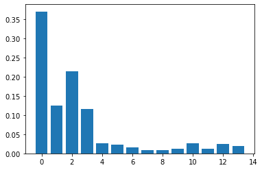

```python
importance = bestRandomForest.feature_importances_

for i,e,o in zip(list(range(0,13)),list(X.columns), importance):
    print("Feature {}: {}, Importance: {}".format(i,e,round(o,4)))

# plot feature importance
plt.bar([x for x in range(len(importance))], importance)
plt.show()
```

**Análisis:** Interpreta el clasificador: - ¿Cuáles son las variables que han tenido más peso? - ¿Has obtenido una buena precisión evaluando en test? - ¿Se ha producido _overfitting_?

- En este segundo modelo las variables más importantes son los ingresos, el monto a financiar, los gatos y el número de hijos
- Este segundo modelo es un poco más preciso detectando las clases del dataset. El accuracy es alto, por lo tanto el modelo tiene mejor performance que el árbol sencillo.
- Si se ha producido porque se nota una gran diferencia entre el accuracy del train y del tes

### 2.4. Predicción de nuevos casos

Hasta ahora hemos entrenado un modelo y hemos evaluado en test para hacernos una idea de la precisión de nuestro modelo con datos reales. Ahora vamos a utilizarlo.

**Implementación:** Suponed que trabajáis en un banco y os visitan clientes que quieren una hipoteca. Aunque se ha de realizar un estudio a fondo de cada caso, así _a priori_ utilizad el clasificador entrenado para tener una idea de si se les concederá la hipoteca o no. - Caso 1: Familia con unos ingresos de 2.000 € y unos gastos de 500 €, la pareja son empresarios y no tienen hijos. Necesitarían para tener la casa de sus sueños una financiación de 200.000 €. - Caso 2: Familia con unos ingresos de 6.000 € y unos gastos de 3.400 €, la pareja uno es asalariado y el otro autónomo con dos hijos a su cargo. Necesitarían para tener la casa de sus sueños una financiación de 320.000 €. - Caso 3: Una mujer soltera con unos ingresos de 9.000 € y unos gastos de 2.250 €, con un hijo a su cargo y de profesión autónoma. Necesitaría una financiación de 39.000 €.

```python
X_train.head(2)
```

|  | ingresos | gastos | financiar | hijos | estado_civil_1 | estado_civil_2 | trabajo_1 | trabajo_2 | trabajo_3 | trabajo_4 | trabajo_5 | trabajo_6 | trabajo_7 | trabajo_8 |
| --- | --- | --- | --- | --- | --- | --- | --- | --- | --- | --- | --- | --- | --- | --- |
| 158 | 2550 | 1017 | 185388 | 3 | 0 | 1 | 0 | 0 | 0 | 0 | 1 | 0 | 0 | 0 |
| 116 | 6744 | 1855 | 405527 | 1 | 1 | 0 | 0 | 0 | 0 | 0 | 0 | 0 | 0 | 1 |

```python
data = [(2000,500,200000,0,1,0,0,0,0,0,0,0,0,1),
        (6000,3400,320000,2,1,0,0,0,0,0,0,1,0,0),
        (9000,2250,39000,1,0,0,1,0,0,0,0,0,0,0)]

df = pd.DataFrame(data, columns= X.columns)
```

```python
df
```

|  | ingresos | gastos | financiar | hijos | estado_civil_1 | estado_civil_2 | trabajo_1 | trabajo_2 | trabajo_3 | trabajo_4 | trabajo_5 | trabajo_6 | trabajo_7 | trabajo_8 |
| --- | --- | --- | --- | --- | --- | --- | --- | --- | --- | --- | --- | --- | --- | --- |
| 0 | 2000 | 500 | 200000 | 0 | 1 | 0 | 0 | 0 | 0 | 0 | 0 | 0 | 0 | 1 |
| 1 | 6000 | 3400 | 320000 | 2 | 1 | 0 | 0 | 0 | 0 | 0 | 0 | 1 | 0 | 0 |
| 2 | 9000 | 2250 | 39000 | 1 | 0 | 0 | 1 | 0 | 0 | 0 | 0 | 0 | 0 | 0 |

```python
y_new_pred = bestRandomForest.predict(df)
```

```python
y_new_pred
```

```
array([0, 1, 1], dtype=int64)
```

Se aprobarían los casos 2 y 3 y se rechazaría el 1